# Journalists

Sylvan Zheng

# Journalists and Balance

- What is driving trends/variation in balance news production?
- Our argument: changing norms in newsroom as a reaction to Trump
  - This could be editors/newsrooms becoming more accepting or even preferring unbalanced articles
  - But there could also be journalist level heterogeneity (Boxell and Conway, 2022)

# Journalists vs Outlets

- Journalists explain variation in balance better than outlets

## Comparing R2

- Look at journalists who write more than 2 articles
- Outlet fixed effect explains almost no variation in balance (R2 = 0)
- R2 using journalist fixed effect way higher than outlet level fixed effect (R2 = 0.17)

```r
df.j <- df %>%
    left_join(authors %>% select(author_name, n) %>% rename(n_articles = n)) %>%
    filter(n_articles > 2, !is.na(author_name))
etable(
    feols(balance ~ source, data = df.j),
    feols(balance ~ 1 | author_name, data = df.j)
) %>% htmlTable()
```

|  |  | feols(balance ~ .. | feols(.. |
| --- | --- | --- | --- |
| 1 | Dependent Var.: | balance | balance |
| 2 |  |  |  |
| 3 | Constant | 0.3636*** (0.0358) |  |
| 4 | sourceLosAngelesTimes | -0.0758. (0.0391) |  |
| 5 | sourceNewYorkTimes | -0.0227 (0.0372) |  |
| 6 | sourceUSAToday | -0.1000* (0.0472) |  |
| 7 | sourceWallStreetJournal | 0.0022 (0.0391) |  |
| 8 | sourceWashingtonPost | 0.0238 (0.0374) |  |
| 9 | Fixed-Effects: | —————— | ——– |
| 10 | author_name | No | Yes |
| 11 | _______________________ | __________________ | ________ |
| 12 | S.E. type | IID | – |
| 13 | Observations | 6,405 | 6,405 |
| 14 | R2 | 0.00586 | 0.16942 |

## SD of balance lower in journalists than outlets

- Another way to show this is that the SD of journalist balance is smaller than outlet level balance

```r
osds <- df.j %>%
    group_by(source) %>%
    summarize(
        balance_sd = sd(balance, na.rm = T),
        n_articles = n()
    )
osds$balance_sd %>% mean()
```

```
## [1] 0.4700477
```

```r
sds <- df.j %>%
    group_by(author_name) %>%
    summarize(
        balance_sd = sd(balance, na.rm = T),
        n_articles = n()
    )
sds$balance_sd %>% mean(na.rm = T)
```

```
## [1] 0.3302191
```

## Movers Only

- We can leverage the (small) number of journalist who move between newspapers in our sample
- With journalist fixed effect, look at variation associated with different outlets. Mostly null.
- Admittedly, there is an effect for USA Today, TODO to figure out what is going on there

```r
df.m <- df.j %>%
    group_by(author_name) %>%
    mutate(n_newspapers = length(unique(source))) %>%
    filter(n_newspapers > 1)
df.m$author_name %>%
    unique() %>%
    length()
```

```
## [1] 73
```

```r
etable2(list(
    feols(balance ~ source | author_name, data = df.m),
    feols(balance ~ source | author_name + year, data = df.m)
), here("paper/tables/switchers.tex"))
```

|  |  | model 1 | model 2 |
| --- | --- | --- | --- |
| 1 | Dependent Var.: | balance | balance |
| 2 |  |  |  |
| 3 | sourceLosAngelesTimes | 0.06 (0.09) | 0.07 (0.09) |
| 4 | sourceNewYorkTimes | 0.04 (0.05) | 0.03 (0.05) |
| 5 | sourceUSAToday | -0.39* (0.18) | -0.37* (0.18) |
| 6 | sourceWallStreetJournal | 0.17 (0.17) | 0.20 (0.17) |
| 7 | sourceWashingtonPost | 0.09 (0.08) | 0.09 (0.08) |
| 8 | Fixed-Effects: | ————- | ————- |
| 9 | author_name | Yes | Yes |
| 10 | year | No | Yes |
| 11 | _______________________ | _____________ | _____________ |
| 12 | S.E.: Clustered | by: author_.. | by: author_.. |
| 13 | Observations | 3,345 | 3,345 |
| 14 | R2 | 0.10753 | 0.11244 |
| 15 | Within R2 | 0.00214 | 0.00214 |

# Within Journalist Analysis

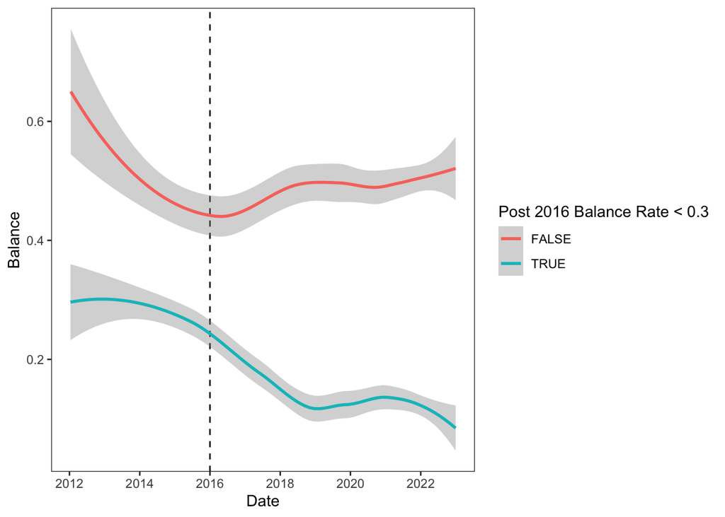

```r
df.an <- df %>%
    filter(year > 2016) %>%
    group_by(author_name) %>%
    summarize(balance_rate = sum(balance, na.rm = T) / sum(!is.na(balance))) %>%
    filter(!is.na(balance_rate))
df.a <- df %>%
    left_join(df.an) %>%
    mutate(
        treat = balance_rate < 0.3,
    )
# Raw trends
df.a %>%
    filter(!is.na(treat)) %>%
    ggplot(aes(x = date, y = as.numeric(balance), color = treat)) +
    geom_vline(xintercept = as.Date("2016-01-01"), lty = 2) +
    geom_smooth(method = "loess") +
    labs(color = "Post 2016 Balance Rate < 0.3", x = "Date", y = "Balance") +
    theme_min
```

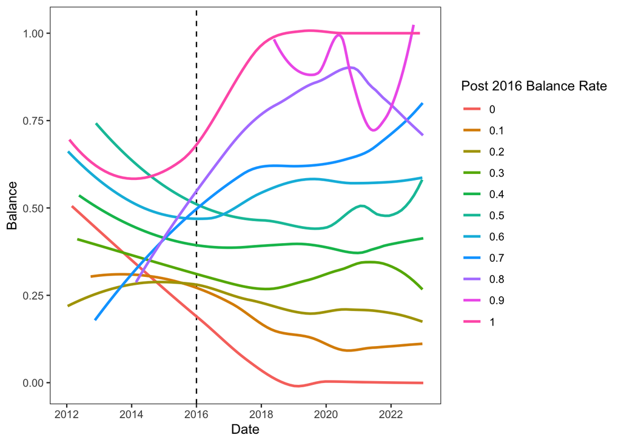

```r
ggsave(here("paper/figures/did-raw-trends.png"), width = 6, height = 4)

df.a %>%
    filter(!is.na(treat)) %>%
    ggplot(aes(x = date, y = as.numeric(balance), color = as.factor(round(balance_rate, digits = 1)))) +
    geom_vline(xintercept = as.Date("2016-01-01"), lty = 2) +
    geom_smooth(method = "loess", se = F) +
    labs(color = "Post 2016 Balance Rate", x = "Date", y = "Balance") +
    theme_min
```

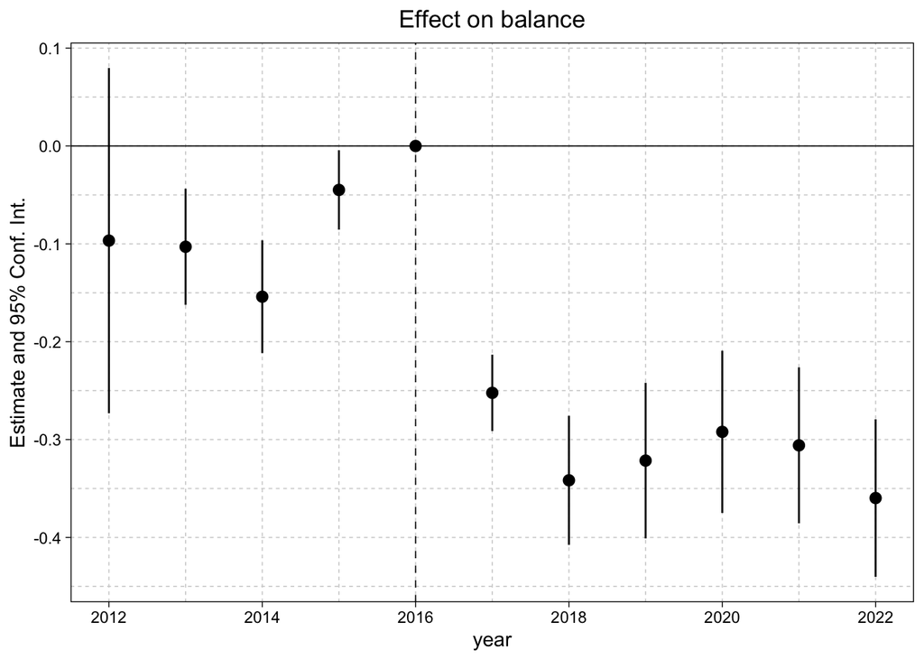

```r
make_did_model <- function(df, thresh = 0.3) {
    df.an <- df %>%
        filter(year > 2016) %>%
        group_by(author_name) %>%
        summarize(balance_rate = sum(balance, na.rm = T) / sum(!is.na(balance))) %>%
        filter(!is.na(balance_rate))
    df.a <- df %>%
        left_join(df.an) %>%
        mutate(
            treat = balance_rate < thresh
        )
    feols(balance ~ i(year, treat, ref = 2016) | year + author_name, df.a)
}
models <- lapply(seq(0.2, 0.5, 0.1), \(t) make_did_model(df, t))
ggiplot(models[[2]])
```

```r
ggsave(here("paper/figures/did-event-study.png"), width = 6, height = 4)
etable2(models[[2]], here("paper/tables/did.tex"))
```

|  |  | models |
| --- | --- | --- |
| 1 | Dependent Var.: | balance |
| 2 |  |  |
| 3 | treat x year = 2012 | -0.10 (0.08) |
| 4 | treat x year = 2013 | -0.10** (0.03) |
| 5 | treat x year = 2014 | -0.15*** (0.03) |
| 6 | treat x year = 2015 | -0.04* (0.02) |
| 7 | treat x year = 2017 | -0.25*** (0.02) |
| 8 | treat x year = 2018 | -0.34*** (0.03) |
| 9 | treat x year = 2019 | -0.32*** (0.04) |
| 10 | treat x year = 2020 | -0.29*** (0.04) |
| 11 | treat x year = 2021 | -0.31*** (0.04) |
| 12 | treat x year = 2022 | -0.36*** (0.04) |
| 13 | Fixed-Effects: | ————— |
| 14 | year | Yes |
| 15 | author_name | Yes |
| 16 | ___________________ | _______________ |
| 17 | S.E.: Clustered | by: year |
| 18 | Observations | 7,909 |
| 19 | R2 | 0.24723 |
| 20 | Within R2 | 0.00767 |

## Robust to different thresholds

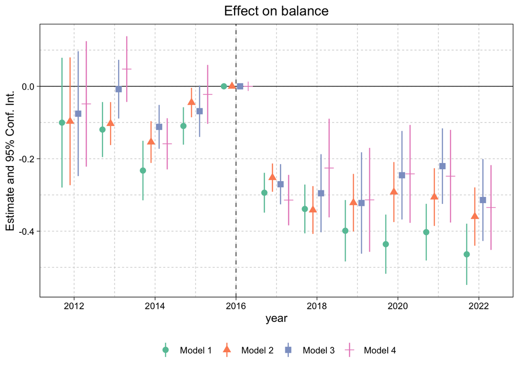

```r
ggiplot(models)
```

```r
ggsave(here("paper/figures/did-event-study-robust.png"), width = 6, height = 4)
```

## Demographics of the treated group

This aligns with our cross sectional analysis

```r
etable2(
    list(
        feols(make_fmla("treat"), data = df.a),
        feols(make_fmla("balance_rate"), data = df.a)
    ),
    here("paper/tables/treat-demo.tex")
)
```

|  |  | model 1 | model 2 |
| --- | --- | --- | --- |
| 1 | Dependent Var.: | treat | balance_rate |
| 2 |  |  |  |
| 3 | elite_undergrad_ivyplusTRUE | -0.21*** (0.03) | 0.07*** (0.01) |
| 4 | edu.has_postgradTRUE | -0.06* (0.02) | -0.02 (0.009) |
| 5 | field.journoTRUE | -0.03 (0.03) | 0.04* (0.01) |
| 6 | age_est_2017>37TRUE | -0.13*** (0.02) | 0.05*** (0.010) |
| 7 | gendermale | 0.19*** (0.04) | -0.02 (0.01) |
| 8 | race.nonwhiteTRUE | 0.09 (0.05) | -0.04 (0.02) |
| 9 | Fixed-Effects: | ————— | ————— |
| 10 | year | Yes | Yes |
| 11 | source | Yes | Yes |
| 12 | ___________________________ | _______________ | _______________ |
| 13 | S.E.: Clustered | by: year | by: year |
| 14 | Observations | 9,981 | 9,981 |
| 15 | R2 | 0.17082 | 0.09704 |
| 16 | Within R2 | 0.10265 | 0.04422 |

# Is there replacement happening?

- Maybe new journalists coming in are different than old journalists
- New journalists write less balanced articles?
- Analysis suggests this is happening a little bit, but not super clear in the data

## Age analysis

```r
yvars <- c("n", "balance", "cfscore.sd", "cfscore.median")
models <- c(
    make_models(df, yvars, covariates = c("age_est"))
)
etable2(models, here("paper/tables/age-balance.tex"))
```

|  |  | model 1 | model 2 | model 3 | model 4 |
| --- | --- | --- | --- | --- | --- |
| 1 | Dependent Var.: | n | balance | cfscore.sd | cfscore.median |
| 2 |  |  |  |  |  |
| 3 | age_est | -0.004 (0.005) | 0.002 (0.001) | 0.0001 (0.0007) | 0.001 (0.0009) |
| 4 | Fixed-Effects: | ————– | ————- | ————— | ————– |
| 5 | year | Yes | Yes | Yes | Yes |
| 6 | source | Yes | Yes | Yes | Yes |
| 7 | _______________ | ______________ | _____________ | _______________ | ______________ |
| 8 | S.E.: Clustered | by: author_n.. | by: author_.. | by: author_name | by: author_n.. |
| 9 | Observations | 11,321 | 8,075 | 6,622 | 9,028 |
| 10 | R2 | 0.05276 | 0.01326 | 0.01054 | 0.04124 |
| 11 | Within R2 | 0.00022 | 0.00187 | 9.93e-6 | 0.00057 |

## Cohort Analysis

- For each journalist, identify their first year in the data

```r
cohort <- df %>%
    group_by(author_name) %>%
    summarize(
        cohort = year(min(as.Date(date), na.rm = T))
    )
cohort$cohort %>% table(useNA = "ifany")
```

```
## .
## 2012 2013 2014 2015 2016 2017 2018 2019 2020 2021 2022
##  116  134  140  148  102  177  133  240  142  288  223
```

```r
df.c <- df %>% left_join(cohort)
etable2(list(
    feols(balance ~ cohort, data = df.c),
    feols(balance ~ cohort > 2016, data = df.c)
), here("paper/tables/cohort.tex"))
```

|  |  | model 1 | model 2 |
| --- | --- | --- | --- |
| 1 | Dependent Var.: | balance | balance |
| 2 |  |  |  |
| 3 | Constant | 16.2*** (3.0) | 0.34*** (0.006) |
| 4 | cohort | -0.008*** (0.002) |  |
| 5 | cohort>2016 |  | -0.05*** (0.01) |
| 6 | _______________ | _________________ | _______________ |
| 7 | S.E. type | IID | IID |
| 8 | Observations | 9,186 | 9,186 |
| 9 | R2 | 0.00296 | 0.00288 |
| 10 | Adj. R2 | 0.00285 | 0.00277 |

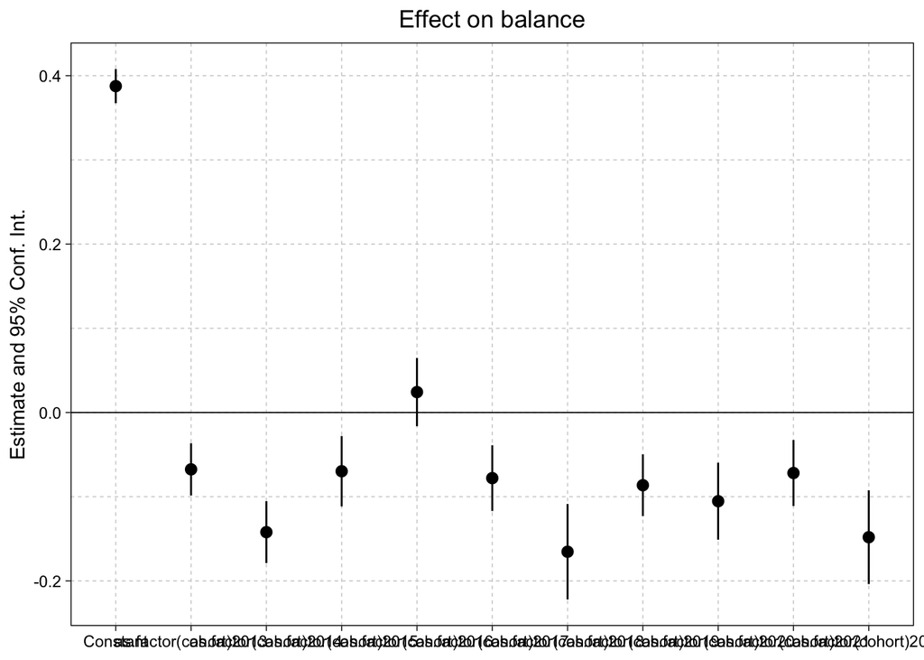

```r
ggcoefplot(feols(balance ~ as.factor(cohort), data = df.c))
```

```r
ggsave(here("paper/figures/cohort-plot.png"), width = 6, height = 4)
```

# Appendix/Supplementary Analysis

## Cross Section shows demographics are related to balance

```r
df.rn <- sources %>%
    calculate_balance(
        types = c("org_category", "cfscore"),
        articles_df = articles
    )
```

### Robust to varying specifications

Plot coefficients for a set of different regression specifications:

1. Main specification (Newspaper fixed effects, Impute journalist education)
2. Newspaper fixed effects, No journalist education imputation
3. No newspaper fixed effects, journalist education imputation
4. No newspaper fixed effects, no journalist education imputation

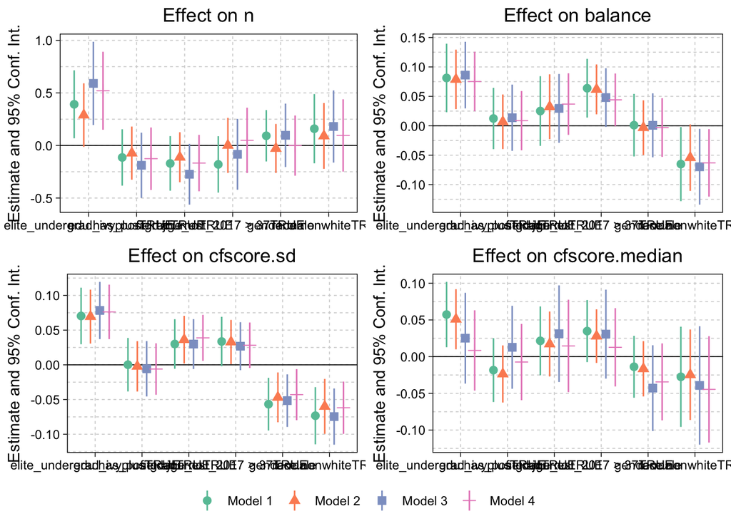

```r
models <- list(
    make_models(df.rn, yvars),
    make_models(df, yvars),
    make_models(df.rn, yvars, festring = "| year"),
    make_models(df, yvars, festring = "| year")
)
cplots <- lapply(1:length(yvars), \(i) {
    ymods <- lapply(models, \(m) m[[i]])
    ggcoefplot(ymods)
})
ggarrange(plotlist = cplots, common.legend = T, legend = "bottom")
```

```r
ggsave(here("paper/figures/coefplot-robust-1.png"), width = 7, height = 7)
```

### Robust to varying cfscore thresholds

Plot balance effects for different thresholds of cfscore variation

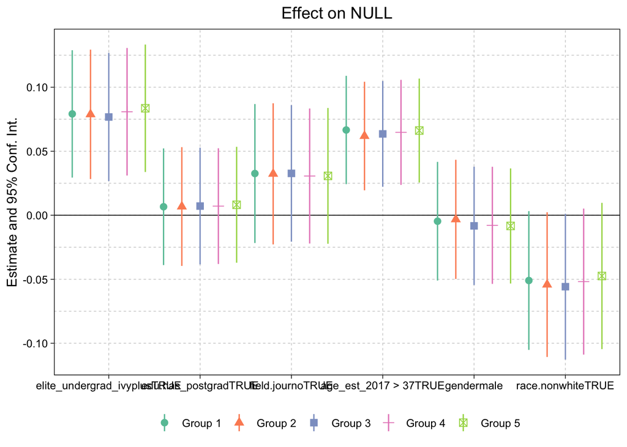

```r
models <- lapply(seq(0.1, 0.5, 0.1), \(t) {
    df.t <- sources %>%
        calculate_balance(
            types = c("org_category", "cfscore"),
            thresh = t,
        )
    make_models(df.t, c("balance"))
})
ggcoefplot(models)
```

```r
ggsave(here("paper/figures/coefplot-robust-2.png"), width = 6, height = 4)
```

Plot effects for different thresholds of imputation strategy

1. Main specification
2. Impute all (No DIME scores)
3. Impute off (Only DIME scores)

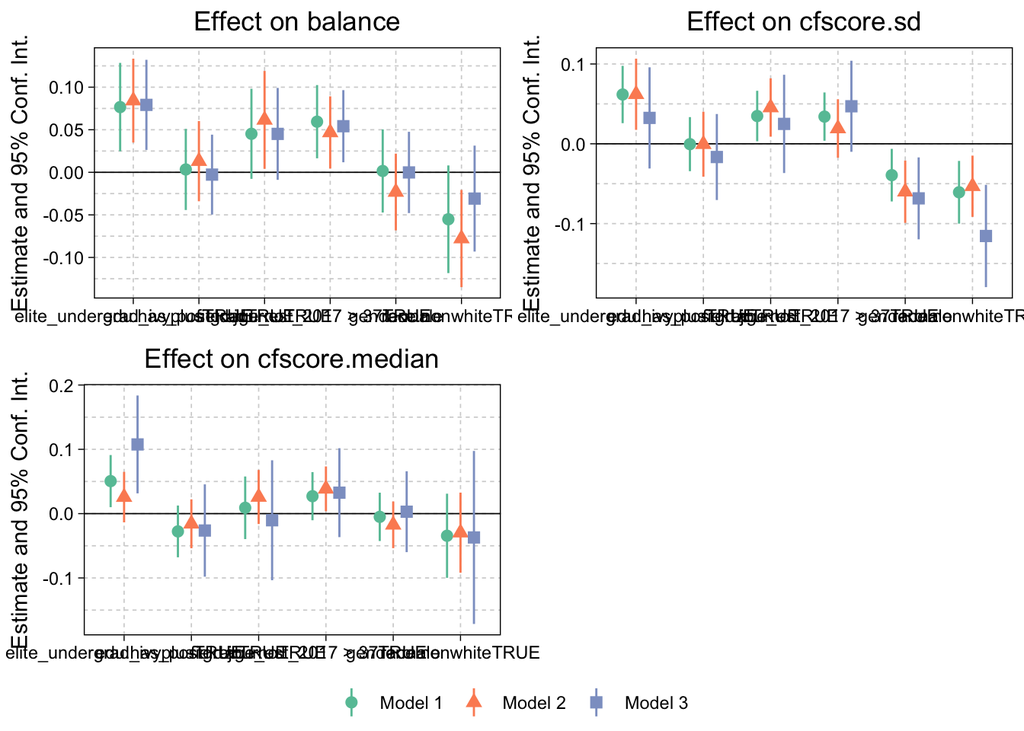

```r
models <- list(
    list(pols = F, impute.all = F, impute.off = F, nwd.sd.thresh = 0.8),
    list(pols = F, impute.all = T, impute.off = F, nwd.sd.thresh = 0.8),
    list(pols = F, impute.all = F, impute.off = T, nwd.sd.thresh = 0.8)
) %>% lapply(\(c) {
    df.t <- sources %>%
        calculate_balance(
            types = c("org_category", "cfscore"),
            cfscore.options = c,
        )
    make_models(df.t, c("balance", "cfscore.sd", "cfscore.median"))
})
cplots <- lapply(1:3, \(i) {
    ymods <- lapply(models, \(m) m[[i]])
    ggcoefplot(ymods)
})
ggarrange(plotlist = cplots, common.legend = T, legend = "bottom")
```

```r
ggsave(here("paper/figures/coefplot-robust-3.png"), width = 7, height = 7)
```

### Robust to varying age specification

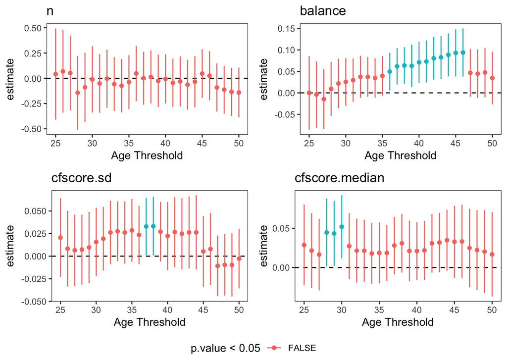

```r
models <- seq(25, 50) %>% lapply(\(age) {
    make_models(df, yvars, j_covars(age))
})
cplots <- lapply(1:4, \(i) {
    ymods <- lapply(models, \(m) tidy(m[[i]]))
    ymods %>%
        bind_rows() %>%
        filter(str_detect(term, "age_est_2017")) %>%
        mutate(age = str_remove(term, "age_est_2017 > ") %>% str_remove("TRUE")) %>%
        ggplot(aes(x = as.numeric(age), y = estimate, ymax = 1.96 * std.error + estimate, ymin = estimate - 1.96 * std.error, color = p.value < 0.05)) +
        geom_hline(yintercept = 0, lty = 2) +
        geom_errorbar(width = 0) +
        geom_point() +
        labs(title = yvars[[i]], x = "Age Threshold") +
        theme_min
})
ggarrange(plotlist = cplots, common.legend = T, legend = "bottom")
```

```r
ggsave(here("paper/figures/coefplot-robust-4.png"), width = 7, height = 7)
```

## Demographic Differences over Time

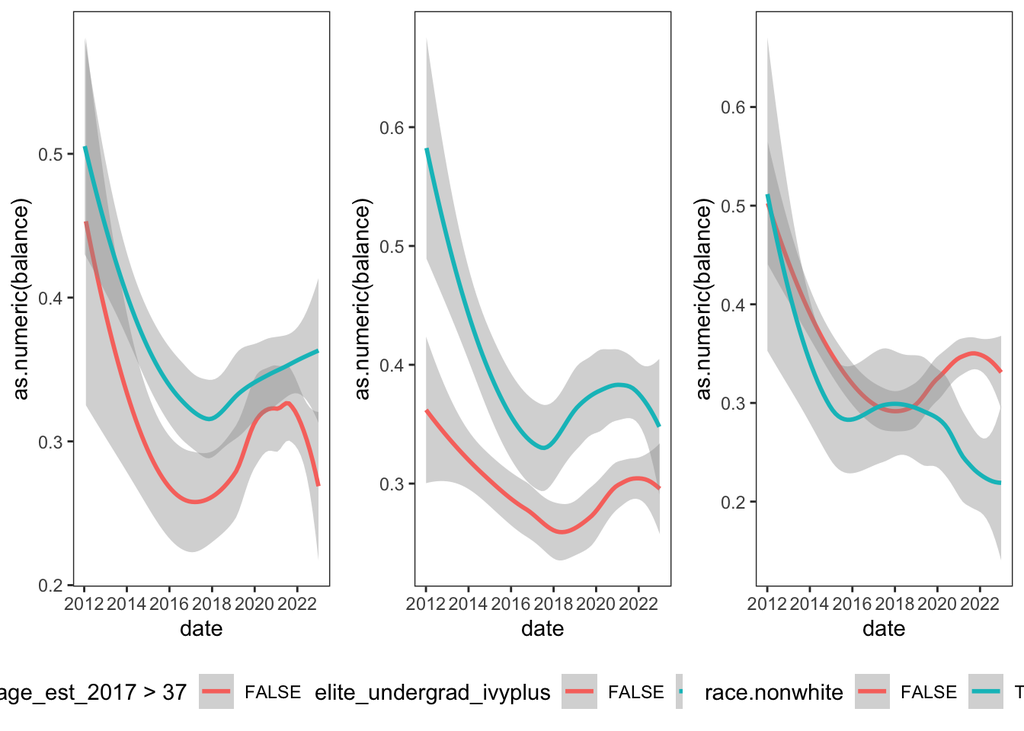

```r
# Age
ggarrange(plotlist = list(
    df %>%
        filter(!is.na(age_est)) %>%
        ggplot(aes(x = date, y = as.numeric(balance), color = age_est_2017 > 37)) +
        geom_smooth(method = "loess") +
        theme_min,
    # Edu
    df %>%
        filter(!is.na(elite_undergrad_ivyplus)) %>%
        ggplot(aes(x = date, y = as.numeric(balance), color = elite_undergrad_ivyplus)) +
        geom_smooth(method = "loess") +
        theme_min,
    # Race
    df %>%
        filter(!is.na(race.nonwhite)) %>%
        ggplot(aes(x = date, y = as.numeric(balance), color = race.nonwhite)) +
        geom_smooth(method = "loess") +
        theme_min
), nrow = 1, legend = "bottom")
```

## Demographic regression before and after 2016

```r
df.p <- df.a %>%
    filter(!is.na(balance_rate))
interactions <- sapply(j_covars(), \(j) sprintf("%s * post2016", j))
etable(
    feols(make_fmla("balance", interactions, festring = ""), data = df.p),
    feols(make_fmla("balance", interactions, festring = "| source"), data = df.p),
    feols(make_fmla("balance", interactions, festring = "| author_name"), data = df.p)
) %>% htmlTable()
```

|  |  | feols(make_fmla(.. | feols(make_fml.. | feols(make_fml.. |
| --- | --- | --- | --- | --- |
| 1 | Dependent Var.: | balance | balance | balance |
| 2 |  |  |  |  |
| 3 | Constant | 0.2883*** (0.0425) |  |  |
| 4 | elite_undergrad_ivyplusTRUE | 0.1175** (0.0368) | 0.1159* (0.0389) |  |
| 5 | post2016TRUE | -0.0178 (0.0461) | 0.0275 (0.0637) | -0.0154 (0.0746) |
| 6 | edu.has_postgradTRUE | 0.0808* (0.0335) | 0.0749 (0.0392) |  |
| 7 | field.journoTRUE | -0.0010 (0.0383) | -0.0069 (0.0481) |  |
| 8 | age_est_2017>37TRUE | 0.0702* (0.0334) | 0.1150* (0.0418) |  |
| 9 | gendermale | -0.0317 (0.0310) | -0.0182 (0.0730) |  |
| 10 | race.nonwhiteTRUE | 0.0046 (0.0515) | 0.0145 (0.0415) |  |
| 11 | elite_undergrad_ivyplusTRUE x post2016TRUE | -0.0468 (0.0393) | -0.0401 (0.0445) | -0.0209 (0.0716) |
| 12 | post2016TRUE x edu.has_postgradTRUE | -0.0698. (0.0359) | -0.0707 (0.0582) | -0.0628 (0.0574) |
| 13 | post2016TRUE x field.journoTRUE | 0.0416 (0.0413) | 0.0407 (0.0476) | -0.0067 (0.0773) |
| 14 | post2016TRUE x age_est_2017>37TRUE | -0.0345 (0.0355) | -0.0640 (0.0378) | -0.0043 (0.0551) |
| 15 | post2016TRUE x gendermale | 0.0263 (0.0334) | 0.0109 (0.0633) | -0.0260 (0.0569) |
| 16 | post2016TRUE x race.nonwhiteTRUE | -0.0685 (0.0548) | -0.0706 (0.0433) | -0.0170 (0.0890) |
| 17 | Fixed-Effects: | —————— | —————- | —————- |
| 18 | source | No | Yes | No |
| 19 | author_name | No | No | Yes |
| 20 | ________________________________________ | __________________ | ________________ | ________________ |
| 21 | S.E. type | IID | by: source | by: author_name |
| 22 | Observations | 7,373 | 7,373 | 7,373 |
| 23 | R2 | 0.01555 | 0.02416 | 0.21266 |
| 24 | Within R2 | – | 0.01597 | 0.00275 |

Interactions here do not necessarily show that much.